# reshape2包与plyr包

徐静

2017年7月29日晚

## 0.1 转载声明

文档以同步至[徐静的GitHub](https://github.com/DataXujing/reshape2_plyr_helpdoc),转载请声明。

## 0.2 reshape2:数据重塑计算

数据处理中常用的函数：`subset`, `transform`, `with`, `stack`, `unstack`, `merge`, `aggregate`, `colMeans`, `split`, `unsplit` ……

reshape2是为数据重塑计算而生的包，是reshape的改良版（现在不怎么提这个包了），reshape中两个比较重要的函数： `melt`,`dcast`。`melt`和`dcast`正如同是铁匠的两种得力工具，`melt`可以看作是炼炉，负责融合数据，成为一个纯粹的长型。而`dcast`则可以看作是铁锤，负责重铸数据，使之成为需要的格式，同时加以分析。下面的例子就是将之前生成的数据进行汇总计算

### 0.2.1 melt

`melt`函数，将一个宽型数据融合成一个长型数据。例如我们将iris数据集进行融合。

```r
library(reshape2)
iris_long <- melt(data=iris,     # 要融合的对象
                  id='Species')  # 哪些变量不参与到融合中
head(iris_long)
```

| Species | variable | value |
| --- | --- | --- |
| setosa | Sepal.Length | 5.1 |
| setosa | Sepal.Length | 4.9 |
| setosa | Sepal.Length | 4.7 |
| setosa | Sepal.Length | 4.6 |
| setosa | Sepal.Length | 5.0 |
| setosa | Sepal.Length | 5.4 |

一个纯粹的长型数据，只包含一个数值变量，其它均为分类变量。而一个纯粹的宽型数据，则不包含分类变量，均为数值变量。而现实中你遇到要处理的数据，则多半是二者的混杂，正如iris数据集那样。

### 0.2.2 dcast

`dcast`的思路和`aggregate`很相似，都是根据变量切分数据，再对分组后的数据进行计算，但dcast的输出格式和功能在多维情况下要方便很多。

> 数据中已经存在分类变量，例如sex或者smoke

> 根据分类变量划分数据

> 再计算某个数值变量的指标

```r
subdata <- iris[,4:5]
dcast(data=subdata,             # 分析对象
      formula=Species~.,        # 数据分组的方式
      value.var='Petal.Width',  # 要计算的数值对象
      fun=mean)
```

| Species | . |
| --- | --- |
| setosa | 0.246 |
| versicolor | 1.326 |
| virginica | 2.026 |

```r
dcast(data=iris_long,
      formula=Species~variable,
      value.var='value',fun=mean)
```

| Species | Sepal.Length | Sepal.Width | Petal.Length | Petal.Width |
| --- | --- | --- | --- | --- |
| setosa | 5.006 | 3.428 | 1.462 | 0.246 |
| versicolor | 5.936 | 2.770 | 4.260 | 1.326 |
| virginica | 6.588 | 2.974 | 5.552 | 2.026 |

```r
dcast(tips,sex~.,value.var='tip',fun=mean)
```

| sex | . |
| --- | --- |
| Female | 2.833448 |
| Male | 3.089618 |

```r
dcast(tips,sex~size,value.var='tip',fun=mean)
```

| sex | 1 | 2 | 3 | 4 | 5 | 6 |
| --- | --- | --- | --- | --- | --- | --- |
| Female | 1.276667 | 2.528448 | 3.250000 | 4.021111 | 5.14 | 4.60 |
| Male | 1.920000 | 2.614184 | 3.476667 | 4.172143 | 3.75 | 5.85 |

### 0.2.3 更复杂的要求1

如果我们想同时计算出不同性别顾客的小费和总费用。但现有的数据集中并没有这种分类变量，怎么处理呢？ 一种是笨一点的方法，将前面用过的方法用两次，然后合并这两个结果。但这种方法在多变量情况下并不好。

> 法①

```r
dcast(tips,sex~.,value.var='tip',fun=mean)
```

| sex | . |
| --- | --- |
| Female | 2.833448 |
| Male | 3.089618 |

```r
dcast(tips,sex~.,value.var='total_bill',fun=mean)
```

| sex | . |
| --- | --- |
| Female | 18.05690 |
| Male | 20.74408 |

> 法②：另一种推荐的方法就是使用前面提到的melt函数，先将数据融合成纯粹的长型数据，再用dcast重铸。

```r
tips_melt <- melt(data = tips,
              id.vars=c('sex','smoker','time','size','day'))
dcast(data = tips_melt, sex ~ variable,
          value.var='value',fun= mean)
```

| sex | total_bill | tip |
| --- | --- | --- |
| Female | 18.05690 | 2.833448 |
| Male | 20.74408 | 3.089618 |

### 0.2.4 更复杂的要求2

要同时考虑不同性别和吸烟习惯的顾客给小费的相对例。在dcast函数中的公式同时考虑到了三个分类变量，在第二步计算了小费相对于总餐费的比率，可以清楚的看到，吸烟的女性顾客相对是最大方的，而吸烟的男性则是最小气的。

```r
tips_mean <- dcast(data = tips_melt, sex+ smoker~ variable, fun= mean)
tips_mean$rate <- with(tips_mean,tip/total_bill)
tips_mean
```

| sex | smoker | total_bill | tip | rate |
| --- | --- | --- | --- | --- |
| Female | No | 18.10519 | 2.773519 | 0.1531892 |
| Female | Yes | 17.97788 | 2.931515 | 0.1630623 |
| Male | No | 19.79124 | 3.113402 | 0.1573122 |
| Male | Yes | 22.28450 | 3.051167 | 0.1369188 |

## 0.3 强大的数据汇总：plyr包

`apply`函数族为我们解决了很大的数据魂汇总问题，这部分内容我们主要讲解plyr包的使用。

### 0.3.1 Split-Apply-Combine

把一个大问题拆分（split）成可以操作的小问题，独立地对每个小问题进行处理（apply），再把所有的小问题处理后的结果再组合起来（combine）

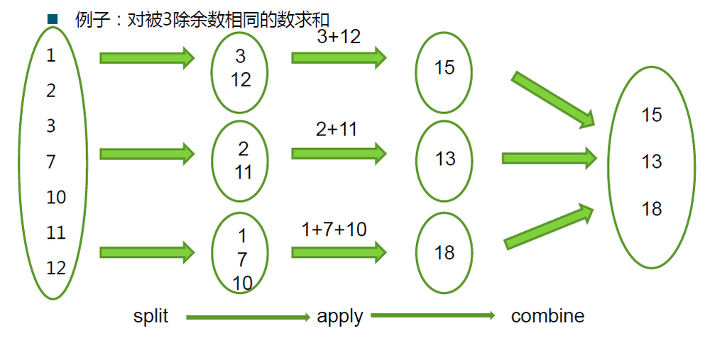

> 这种思想贯穿一个数据分析过程的始终

> 数据准备 例如创建进行分组后更容易计算的新的变量（例如分组进行排序，标准化，正态化）

> 建模 例如对不同类型的数据运用不同的模型  进行总结或者分析 例如计算均值，方差等

> 存在并行运算的思想，对应于一个高度平行的环境，可以通过充分利用计算资源从而提高效率

1 作者

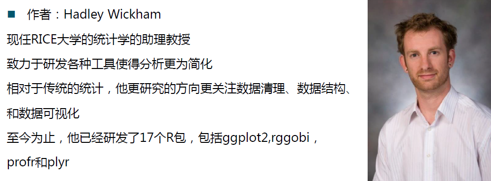

2 作者对包的描述

**plyr，a package that generalises and standardises the apply family of functions for problems that require you to split up a large data structure into multiple pieces, apply a function to each piece and then join the pieces back together**

**（plyr包针对的问题是：把一个庞大的数据结构拆分成多个片段，然后分别对这些片段应用函数，然后再把片段函数结构组合起来）**

3 plyr包的基本思想： Split-Apply-Combine

4 plyr包的有点：

**替代很多问题中复杂的循环（loops）**

**从数据结构中的细节脱离出来**

**可以减少多余的代码和突出计算中的关键要素**

5 plyr包的不足

**其函数假设把数据切分成不重复的小片段，但是对于需要重复用到的数据的时候就不能直接用函数解决 例子：1,2,3,4中分别计算奇数和大于2的数的均值**

**当计算中需要用到之前循环中前面迭代的结果**

6 plyr包的基本函数

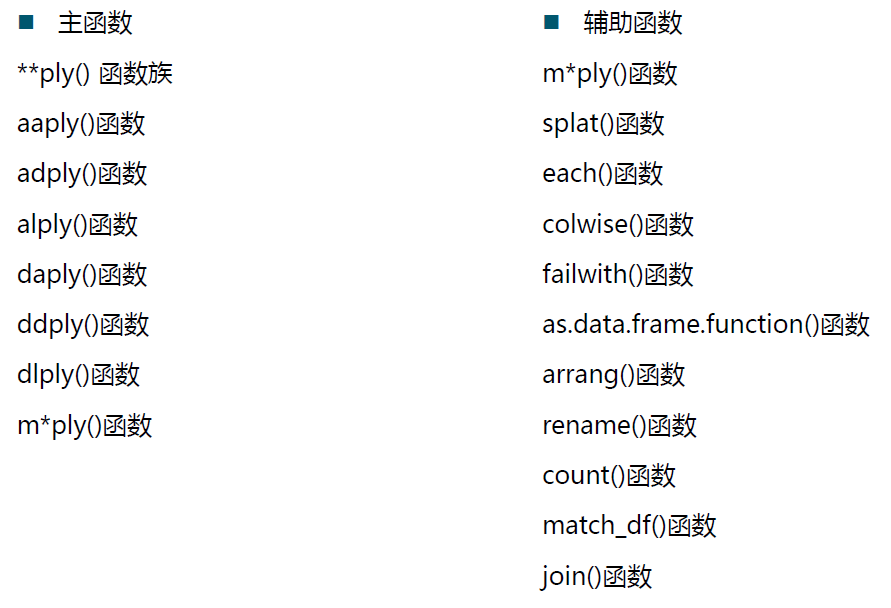

### 0.3.3 主函数介绍（**ply)

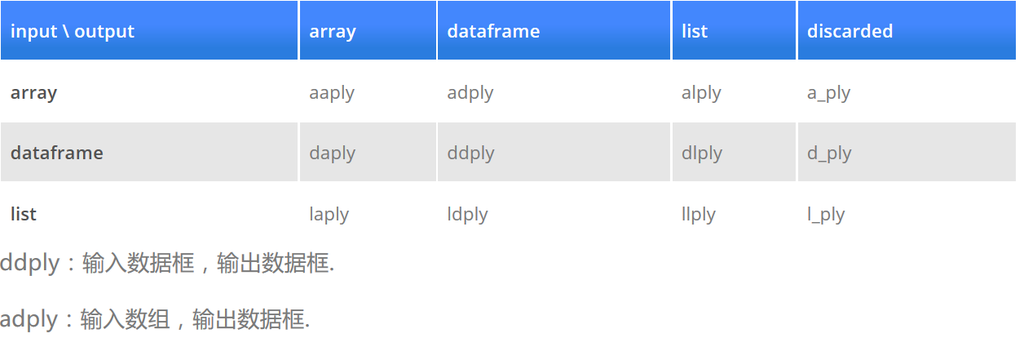

```r
ratio_fun <- function(x) {
    sum(x$tip)/sum(x$total_bill)
}


library(plyr)
ddply(.data=tips,             # 拆分计算的对象
      .variables='sex',       # 按照什么变量来拆分
      .fun=ratio_fun)         # 计算的函数
```

| sex | V1 |
| --- | --- |
| Female | 0.1569178 |
| Male | 0.1489398 |

```r
ddply(tips,.(sex), ratio_fun)
与上述代码及ddply(tips,.'sex', ratio_fun)均等价，习惯plyr的写法
```

```r
a*ply(.data, .margins, .fun, ..., .progress = "none")
参数
data是要进行处理的数组
margins是用哪种方式去切割数据，取值为1，2，c(1,2)
fun是对切割的数据指定一个函数进行处理
progress决定是否显示及用哪种方式显示进度条
```

```r
library(plyr)
library(printr)
a=matrix(1:21,nrow=3,ncol=7)
print(a)
```

```
##      [,1] [,2] [,3] [,4] [,5] [,6] [,7]
## [1,]    1    4    7   10   13   16   19
## [2,]    2    5    8   11   14   17   20
## [3,]    3    6    9   12   15   18   21
```

```r
aaply(.data=a,.margins=1,.fun=mean)
```

```
##  1  2  3
## 10 11 12
```

```r
aaply(a,1,mean)
```

```
##  1  2  3
## 10 11 12
```

```r
aaply(a,2,mean)
```

```
##  1  2  3  4  5  6  7
##  2  5  8 11 14 17 20
```

```r
aaply(a,c(1,2),mean)
```

| 1 | 2 | 3 | 4 | 5 | 6 | 7 |
| --- | --- | --- | --- | --- | --- | --- |
| 1 | 4 | 7 | 10 | 13 | 16 | 19 |
| 2 | 5 | 8 | 11 | 14 | 17 | 20 |
| 3 | 6 | 9 | 12 | 15 | 18 | 21 |

```r
aaply(a,1,mean,.progress="none")
```

```
##  1  2  3
## 10 11 12
```

```r
aaply(a,1,mean,.progress="text")
```

```
##  1  2  3
## 10 11 12
```

```r
aaply(a,1,mean,.progress="win")
```

```
##  1  2  3
## 10 11 12
```

```r
d*ply(.data, .variables, .fun, ..., .progress = "none")
参数
.variables指定要按其分割的变量名称
```

```r
require(plyr)
names=c("John","Mary","Alice","Peter","Roger","Phyillis")
age=c(13,15,14,13,14,13)
sex=c("Male","Female","Female","Male","Male","Female")
data=data.frame(names,age,sex)
```

```r
amean=function(data)
{
agemean=mean(data[,2])
return(agemean)
}
daply(data,.(age),.fun=amean)
```

```
## 13 14 15
## 13 14 15
```

```r
daply(data,.(sex),.fun=amean)
```

```
##   Female     Male
## 14.00000 13.33333
```

```r
daply(data,.(age,sex),.fun=amean)
```

|  | Female | Male |
| --- | --- | --- |
| 13 | 13 | 13 |
| 14 | 14 | 14 |
| 15 | 15 | NA |

```r
ddply(data,.(sex),.fun=amean)
```

| sex | V1 |
| --- | --- |
| Female | 14.00000 |
| Male | 13.33333 |

```r
dlply(data,.(sex),.fun=amean)
```

```
## $Female
## [1] 14
##
## $Male
## [1] 13.33333
##
## attr(,"split_type")
## [1] "data.frame"
## attr(,"split_labels")
##      sex
## 1 Female
## 2   Male
```

```r
l*ply(.data, .fun, ..., .progress = "none")
列表类型的数据是最简单的数据，因为它已经被分割成一个个了（也就是列表数据的一个个元素），所以这类函数没有参数用来描述是按什么进行切分的。
```

```r
a=c(1,2,3,4,1,5,7,8,9,4,2)
b=c(1,2,5,7,6,4,8,7)
c=c(4,8,9,1,2,3,1)
list=list(a,b,c)
llply(list,mean)
laply(list,mean)
ldply(list,mean)
```

[output not shown]

```r
m*ply(.data,.fun=NULL,.inform=FALSE,…)
把array或者dataframe的参数数值放进函数中，得到dataframe（mdply），array（maply）或者list（mlply）
```

```r
data=data.frame(n=c(10,100,50),mean=c(5,5,10),sd=c(1,2,1))
data
```

| n | mean | sd |
| --- | --- | --- |
| 10 | 5 | 1 |
| 100 | 5 | 2 |
| 50 | 10 | 1 |

```r
mlply(data,rnorm)
```

```
## $`1`
##  [1] 5.669808 4.815258 6.315102 4.428802 5.526894 6.489099 3.983583
##  [8] 4.606785 5.301547 4.640648
##
## $`2`
##   [1]  3.2950026  5.6329330  5.5706646  5.3188751  4.2549754  4.3633823
##   [7]  4.5553427  4.0006253  9.2107025  5.5739221  3.2737678  3.8293666
##  [13]  4.3944563  3.0526382  7.5306887 11.4093926  0.8458611  3.9935954
##  [19]  3.8990516  6.7268397  1.7517172  8.9164166 10.6764893  6.5964980
##  [25]  4.2583152  3.7609022  5.4245177  5.8467250  5.0276638  6.1278014
##  [31]  6.9468987  8.9093011  3.1059132  2.9276567  9.1337459  5.6703151
##  [37] -0.1192065  7.9209950  2.6921484  3.0694342  4.9918737  8.0716661
##  [43]  4.8110979  7.4291653  5.4500492  5.7853837  6.0516819  6.0346034
##  [49]  3.8183550  3.5477291  4.6003700  4.5081068  2.8780934  5.4799072
##  [55]  4.5793618  6.9511826  2.5705691  5.4506294  1.5555369  7.4237948
```

[output cut: 25 more lines]

### 0.3.4 plyr包中的辅助函数

```r
splat()函数
作用：与使用众多的参数不同，该函数把原函数中多个参数打包为一个list作为参数，然后输出新的函数
优点：当你想把数据框或者数组里的一行的数据作为参数赋给一个函数，用splat()函数就可以省去人为把数据框拆分的麻烦
m*ply(a_matrix, FUN)的作用和a*ply(a_matrix，1，splat(FUN))一样
```

```r
head(mtcars,5)
```

|  | mpg | cyl | disp | hp | drat | wt | qsec | vs | am | gear | carb |
| --- | --- | --- | --- | --- | --- | --- | --- | --- | --- | --- | --- |
| Mazda RX4 | 21.0 | 6 | 160 | 110 | 3.90 | 2.620 | 16.46 | 0 | 1 | 4 | 4 |
| Mazda RX4 Wag | 21.0 | 6 | 160 | 110 | 3.90 | 2.875 | 17.02 | 0 | 1 | 4 | 4 |
| Datsun 710 | 22.8 | 4 | 108 | 93 | 3.85 | 2.320 | 18.61 | 1 | 1 | 4 | 1 |
| Hornet 4 Drive | 21.4 | 6 | 258 | 110 | 3.08 | 3.215 | 19.44 | 1 | 0 | 3 | 1 |
| Hornet Sportabout | 18.7 | 8 | 360 | 175 | 3.15 | 3.440 | 17.02 | 0 | 0 | 3 | 2 |

```r
hp_per_cyl <- function(hp, cyl, ...) hp / cyl
splat(hp_per_cyl)(mtcars[1,])
```

```
## [1] 18.33333
```

```r
splat(hp_per_cyl)(mtcars)
```

```
##  [1] 18.33333 18.33333 23.25000 18.33333 21.87500 17.50000 30.62500
##  [8] 15.50000 23.75000 20.50000 20.50000 22.50000 22.50000 22.50000
## [15] 25.62500 26.87500 28.75000 16.50000 13.00000 16.25000 24.25000
## [22] 18.75000 18.75000 30.62500 21.87500 16.50000 22.75000 28.25000
## [29] 33.00000 29.16667 41.87500 27.25000
```

```r
colwise(.ffun, .cols, …)
作用：把作用于数据框行向量的函数（如mean，median）转化为作用于数据框列向量的函数，可以结合base R 的函数使用，与d*ply一起使用时十分方便
参数: .fun是要转化的函数；.cols可以是测试数据框的列是否应包含的判别函数或者是· 要包含的列的名称
另外还有衍生的catcolwise()和numcolwise()函数，它们分别针对的是函数只在离散和数值型的变量上操作
```

```r
nmissing=function(x)sum(is.na(x))
colwise(nmissing)(baseball)
```

| id | year | stint | team | lg | g | ab | r | h | X2b | X3b | hr | rbi | sb | cs | bb | so | ibb | hbp | sh | sf | gidp |
| --- | --- | --- | --- | --- | --- | --- | --- | --- | --- | --- | --- | --- | --- | --- | --- | --- | --- | --- | --- | --- | --- |
| 0 | 0 | 0 | 0 | 0 | 0 | 0 | 0 | 0 | 0 | 0 | 0 | 12 | 250 | 4525 | 0 | 1305 | 7528 | 377 | 960 | 7390 | 5272 |

```r
head(ddply(baseball,.(year),colwise(nmissing)),5)
```

| year | id | stint | team | lg | g | ab | r | h | X2b | X3b | hr | rbi | sb | cs | bb | so | ibb | hbp | sh | sf | gidp |
| --- | --- | --- | --- | --- | --- | --- | --- | --- | --- | --- | --- | --- | --- | --- | --- | --- | --- | --- | --- | --- | --- |
| 1871 | 0 | 0 | 0 | 0 | 0 | 0 | 0 | 0 | 0 | 0 | 0 | 0 | 0 | 0 | 0 | 0 | 7 | 7 | 7 | 7 | 7 |
| 1872 | 0 | 0 | 0 | 0 | 0 | 0 | 0 | 0 | 0 | 0 | 0 | 0 | 0 | 0 | 0 | 0 | 13 | 13 | 13 | 13 | 13 |
| 1873 | 0 | 0 | 0 | 0 | 0 | 0 | 0 | 0 | 0 | 0 | 0 | 0 | 0 | 0 | 0 | 0 | 13 | 13 | 13 | 13 | 13 |
| 1874 | 0 | 0 | 0 | 0 | 0 | 0 | 0 | 0 | 0 | 0 | 0 | 0 | 0 | 0 | 0 | 0 | 15 | 15 | 15 | 15 | 15 |
| 1875 | 0 | 0 | 0 | 0 | 0 | 0 | 0 | 0 | 0 | 0 | 0 | 0 | 0 | 0 | 0 | 0 | 17 | 17 | 17 | 17 | 17 |

```r
head(ddply(baseball,.(year),colwise(nmissing,.(sb,cs,so))),5)
```

| year | sb | cs | so |
| --- | --- | --- | --- |
| 1871 | 0 | 0 | 0 |
| 1872 | 0 | 0 | 0 |
| 1873 | 0 | 0 | 0 |
| 1874 | 0 | 0 | 0 |
| 1875 | 0 | 0 | 0 |

```r
head(ddply(baseball,.(year),colwise(nmissing,c("sb","cs","so"))),5)
```

| year | sb | cs | so |
| --- | --- | --- | --- |
| 1871 | 0 | 0 | 0 |
| 1872 | 0 | 0 | 0 |
| 1873 | 0 | 0 | 0 |
| 1874 | 0 | 0 | 0 |
| 1875 | 0 | 0 | 0 |

```r
head(ddply(baseball,.(year),colwise(nmissing,~sb+cs+so)),5)
```

| year | sb | cs | so |
| --- | --- | --- | --- |
| 1871 | 0 | 0 | 0 |
| 1872 | 0 | 0 | 0 |
| 1873 | 0 | 0 | 0 |
| 1874 | 0 | 0 | 0 |
| 1875 | 0 | 0 | 0 |

```r
failwith(default=NULL, f, quiet=FALSE)
作用：修正一个函数，使得当该函数出现错误时返回一个默认值
参数：default；f是要修正的函数；quiet是设定错误信息是否显示，默认值为FALSE，为显是设定要返回的默认值示错误信息
```

```r
arrange(df, .(var1), .(var2)…)
作用：按照列给数据框排序
参数：df为数据框；.var是要按照排序的变量
```

```r
rename(x, replace, warn_missing=TRUE)
作用：通过名字修改名字，而不是根据它的位置
参数：x是要操作的数据；replace是指定的替换的字符向量（包括新的和旧的字符） ；warm_missing是指定当旧的字符不存在于x的时候，是否显示错误信息，默 认值为TRUE，表示显示此信息
```

```r
x=c("a"=1,"b"=2,"c"=3,"d"="c")
x
```

```
##   a   b   c   d
## "1" "2" "3" "c"
```

```r
rename(x,replace=c("b"="c"))
```

```
##   a   c   c   d
## "1" "2" "3" "c"
```

```r
rename(x,replace=c("c"="e"))
```

```
##   a   b   e   d
## "1" "2" "3" "c"
```

```r
rename(x,replace=c("e"="c"))
```

```
##   a   b   c   d
## "1" "2" "3" "c"
```

```r
rename(x,replace=c("e"="c"),warn_missing=FALSE)
```

```
##   a   b   c   d
## "1" "2" "3" "c"
```

```r
count(df， vars=NULL, wt_var=NULL)
作用：数变量中观测值出现的个数
参数：df是要处理的数据框；vars是指定要进行数数的变量；wt_var是指定作为权重 的变量
```

```r
match_df(x, y, on=NULL)
作用：从一个数据框中提取与另一个数据框中相同的行
参数：x是原始的需要提取的数据框；y是用来找出相同行的另一个数据框；on是指定 要来比对的变量，默认为比较两个数据框中所有的变量
```

```r
join(x, y, by=NULL, type=“left”, match=“all”)
作用：联合两个数据框
参数：x，y是两个数据框；by是指定要联合的变量，默认值为所有的变量；type是指 定联合的方式

join(x,y,"x2",type="inner")
join(x,y,"x2",type="right")
join(x,y,"x2",type="full")
y[,2]=c(6,6,6,6)
join(x,y,"x2",type="inner",match="all")
join(x,y,"x2",type="inner",match ="first")

join()函数运行速度要比merge()函数块
first <- ddply(baseball, "id", summarise, first = min(year))
system.time(b2 <- merge(baseball, first, by = "id", all.x = TRUE))
system.time(b3 <- join(baseball, first, by = "id"))
```

## 0.4 Reference

[3] http://www.xueqing.tv/course/64

[4] http://www.xueqing.tv/course/1

[5] http://www.xueqing.tv/course/31

Copyright © 2017 xujing.